# Improvising Risk Prediction of Early Stage Diabetes

**Feature Selection**  
**Method 2: Random Forest Classifier: Feature Importance**

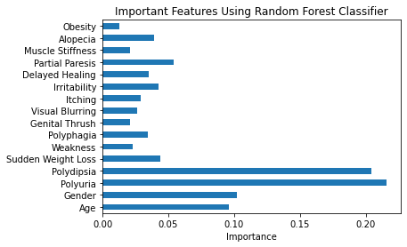

```python
# create a extra tree classifier to be used for feature selection
forest = RandomForestClassifier(n_estimators=250, random_state=0)

# fitting the model
forest.fit(train_data, train_class)

# importances contains the feature importance value for each metric
importances = forest.feature_importances_
# argsort returns the indices that will sort the original array
sortedIndices = np.argsort(importances)

feat_importances = pd.Series(importances, index=features.columns)
feat_importances.plot(kind='barh')
plt.xlabel('Importance')
plt.title('Important Features Using Random Forest Classifier')
plt.show()
```

```python
# Top 10 features
dataset_scores1 = pd.Series(forest.feature_importances_)
dataset_cols1 = pd.Series(features.columns)
data1 = pd.DataFrame({'Feature': dataset_cols1,'Score':dataset_scores1})
top10 = data1.nlargest(10,'Score')
top10
```

|  | Feature | Score |
| --- | --- | --- |
| 2 | Polyuria | 0.215650 |
| 3 | Polydipsia | 0.204280 |
| 1 | Gender | 0.101876 |
| 0 | Age | 0.096161 |
| 12 | Partial Paresis | 0.053991 |
| 4 | Sudden Weight Loss | 0.043865 |
| 10 | Irritability | 0.042849 |
| 14 | Alopecia | 0.038914 |
| 11 | Delayed Healing | 0.035112 |
| 6 | Polyphagia | 0.034419 |

Top 10 features that were identified using the Random Forest Classifier: Feature Importance method were Polyuria, Polydipsia, Gender, Sudden Weight Loss, Partial Paresis, Polyphagia, Irritability, Alopecia, Delayed Healing and Age.

**Feature Selection**  
**Method 3: SelectKBest method using chi-squared statistical test**

```python
best_feature = SelectKBest(score_func=chi2,k=10)
fit = best_feature.fit(features, classes)
dataset_scores = pd.Series(fit.scores_)
dataset_cols = pd.Series(features.columns)
data = pd.DataFrame({'Feature': dataset_cols,'Score':dataset_scores})
data
```

|  | Feature | Score |
| --- | --- | --- |
| 0 | Age | 18.845767 |
| 1 | Gender | 38.747637 |
| 2 | Polyuria | 116.184593 |
| 3 | Polydipsia | 120.785515 |
| 4 | Sudden Weight Loss | 57.749309 |
| 5 | Weakness | 12.724262 |
| 6 | Polyphagia | 33.198418 |
| 7 | Genital Thrush | 4.914009 |
| 8 | Visual Blurring | 18.124571 |
| 9 | Itching | 0.047826 |
| 10 | Irritability | 35.334127 |
| 11 | Delayed Healing | 0.620188 |
| 12 | Partial Paresis | 55.314286 |
| 13 | Muscle Stiffness | 4.875000 |
| 14 | Alopecia | 24.402793 |
| 15 | Obesity | 2.250284 |

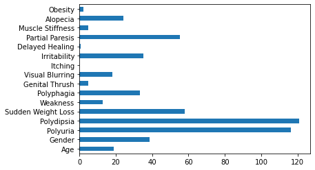

```python
# Plotting the features from SelectKBest method using chi-squared statistical test

feat_importances = pd.Series(fit.scores_, index=features.columns)
feat_importances.plot(kind='barh')
```

```python
# Top 10 features
top = data.nlargest(10,'Score')
top
```

|  | Feature | Score |
| --- | --- | --- |
| 3 | Polydipsia | 120.785515 |
| 2 | Polyuria | 116.184593 |
| 4 | Sudden Weight Loss | 57.749309 |
| 12 | Partial Paresis | 55.314286 |
| 1 | Gender | 38.747637 |
| 10 | Irritability | 35.334127 |
| 6 | Polyphagia | 33.198418 |
| 14 | Alopecia | 24.402793 |
| 0 | Age | 18.845767 |
| 8 | Visual Blurring | 18.124571 |

Top 10 features were identified using the SelectKBest method using chi-squared statistical test. Polyuria, Polydipsia, Gender, Sudden Weight Loss, Partial Paresis, Polyphagia, Irritability, Alopecia, Visual Blurring and Age

```python
# Selecting Best Features

train_features_best = train_features[['Polydipsia','Polyuria','Sudden Weight Loss','Partial Paresis','Gender','Irritability','Polyphagia','Age']]
test_features_best = test_features[['Polydipsia','Polyuria','Sudden Weight Loss','Partial Paresis','Gender','Irritability','Polyphagia','Age']]

# Scaling the Data

scaler = StandardScaler()
train_features_best = scaler.fit_transform(train_features_best)
test_features_best = scaler.transform(test_features_best)
```

**Improvised models: Default Parameters and 8 selected best features**

```python
best_features_results = run_models(train_features_best, test_features_best, train_class, test_class)
best_features_results
```

|  | Model | Test Set Accuracy | Train Cross Val Accuracy | Precision | Recall | F1 Score | ROC Value |
| --- | --- | --- | --- | --- | --- | --- | --- |
| 0 | Logistic Regression | 91.35 | 90.87 | 0.928571 | 0.942029 | 0.935252 | 0.899586 |
| 0 | K-Nearest Neighbors | 96.15 | 91.57 | 0.971429 | 0.971429 | 0.971429 | 0.956303 |
| 0 | Decision Tree | 96.15 | 93.98 | 0.942857 | 1.000000 | 0.970588 | 0.947368 |
| 0 | Support Vector Machine | 95.19 | 90.85 | 0.957143 | 0.971014 | 0.964029 | 0.942650 |
| 0 | Random Forest | 98.08 | 95.42 | 0.971429 | 1.000000 | 0.985507 | 0.972222 |
| 0 | Naive Bayes | 87.50 | 87.75 | 0.885714 | 0.925373 | 0.905109 | 0.854578 |

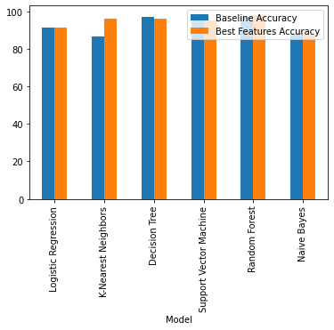

```python
# Comparison graphically of the baseline vs the improvised models

plt.figure(figsize=(20,10))
data = pd.DataFrame({'Model': baseline_results['Model'],'Baseline Accuracy':baseline_results['Test Set Accuracy'],'Best Features Accuracy':best_features_results['Test Set Accuracy']})
data.plot.bar(x="Model", y=["Baseline Accuracy", "Best Features Accuracy"])
plt.show()
```

**Hyperparameter Tuning**  
**Model 1: Random Forest Classifier**

```python
# Hyper Parameter Tuning for Random Forest Classifier
parameters = {
                'criterion' : ['gini', 'entropy'],
                'max_depth': [4, 6],
                'min_samples_leaf': [3, 4, 5],
                'min_samples_split': [8, 10, 12],
                'n_estimators': [10, 50, 100, 200]
            }

# Create a based model
rf_mf = RandomForestClassifier()
# Instantiate the grid search model
grid_search_mf = GridSearchCV(estimator = rf_mf, param_grid = parameters, cv = 5)
grid_search_mf.fit(train_features_best, train_class)

# print best parameter after tuning
print(grid_search_mf.best_params_)

# print how our model looks after hyper-parameter tuning
print(grid_search_mf.best_estimator_)
```

```
{'criterion': 'entropy', 'max_depth': 6, 'min_samples_leaf': 3, 'min_samples_split': 10, 'n_estimators': 50}
RandomForestClassifier(criterion='entropy', max_depth=6, min_samples_leaf=3,
                       min_samples_split=10, n_estimators=50)
```

```python
rf = RandomForestClassifier(criterion='entropy', max_depth=6, min_samples_leaf=3,
                       min_samples_split=10,n_estimators=50)
rf.fit(train_features_best, train_class)
prediction_rf = rf.predict(test_features_best)
tuning_results = pd.DataFrame()
accuracy = accuracy_score(prediction_rf,test_class)
roc_score = roc_auc_score(prediction_rf,test_class)
pre_score = precision_score(prediction_rf,test_class)
rec_score = recall_score(prediction_rf,test_class)
f1 = f1_score(prediction_rf,test_class)

model_results_rf = pd.DataFrame([['Random Forest',round(accuracy*100,2),pre_score,rec_score, f1,roc_score]], columns = ['Model', 'Test Set Accuracy', 'Precision', 'Recall', 'F1 Score','ROC Value'])
tuning_results = tuning_results.append(model_results_rf)
tuning_results
```

|  | Model | Test Set Accuracy | Precision | Recall | F1 Score | ROC Value |
| --- | --- | --- | --- | --- | --- | --- |
| 0 | Random Forest | 95.19 | 0.957143 | 0.971014 | 0.964029 | 0.94265 |

```python
print("CONFUSION MATRIX for Random Forest Classification Model on the Test Data:")
svc_confusion_matrix = confusion_matrix(test_class, prediction_rf)
svc_conf_matrix = pd.DataFrame(data = svc_confusion_matrix, columns = ['Predicted Diabetes', 'Predicted No Diabetes'], index = ['Actual Diabetes', 'Actual No Diabetes'])
print(svc_conf_matrix)
```

```
CONFUSION MATRIX for Random Forest Classification Model on the Test Data:
                    Predicted Diabetes  Predicted No Diabetes
Actual Diabetes                     32                      2
Actual No Diabetes                   3                     67
```

**Hyperparameter Tuning**  
**Model 2: Support Vector Classifier**

```python
# defining parameter range for SVM
parameters = {'C': [0.1, 1, 10, 100, 1000],
              'gamma': [1, 0.1, 0.01, 0.001, 0.0001],
              'kernel': ['rbf','linear', 'poly']}

grid = GridSearchCV(SVC(), parameters, cv = 5)

# fitting the model for grid search
grid.fit(train_features_best, train_class)

# print best parameter after tuning
print(grid.best_params_)

# print how our model looks after hyper-parameter tuning
print(grid.best_estimator_)
```

```
{'C': 100, 'gamma': 1, 'kernel': 'rbf'}
SVC(C=100, gamma=1)
```

```python
svc = SVC(C=100, gamma=1)
svc.fit(train_features_best, train_class)
prediction_svc = svc.predict(test_features_best)

accuracy = accuracy_score(prediction_svc,test_class)
roc_score = roc_auc_score(prediction_svc,test_class)
pre_score = precision_score(prediction_svc,test_class)
rec_score = recall_score(prediction_svc,test_class)
f1 = f1_score(prediction_svc,test_class)

model_results_svc = pd.DataFrame([['Support Vector Machine',round(accuracy*100,2),pre_score,rec_score, f1,roc_score]], columns = ['Model', 'Test Set Accuracy', 'Precision', 'Recall', 'F1 Score','ROC Value'])
tuning_results = tuning_results.append(model_results_svc)

tuning_results
```

|  | Model | Test Set Accuracy | Precision | Recall | F1 Score | ROC Value |
| --- | --- | --- | --- | --- | --- | --- |
| 0 | Random Forest | 95.19 | 0.957143 | 0.971014 | 0.964029 | 0.942650 |
| 0 | Support Vector Machine | 97.12 | 0.971429 | 0.985507 | 0.978417 | 0.964182 |

```python
print("CONFUSION MATRIX for Support Vector Classification Model on the Test Data:")
svc_confusion_matrix = confusion_matrix(test_class, prediction_svc)
svc_conf_matrix = pd.DataFrame(data = svc_confusion_matrix, columns = ['Predicted Diabetes', 'Predicted No Diabetes'], index = ['Actual Diabetes', 'Actual No Diabetes'])
print(svc_conf_matrix)
```

```
CONFUSION MATRIX for Support Vector Classification Model on the Test Data:
                    Predicted Diabetes  Predicted No Diabetes
Actual Diabetes                     33                      1
Actual No Diabetes                   2                     68
```

**Hyperparameter Tuning**  
**Model 3: Decision Tree**

```python
parameters = {"max_depth": [1,2,3,4,5,6,7,10,12],
              "max_features": [5],
              "min_samples_leaf": [1,2,3,4,5,6,7,8,9,10,11],
              "criterion": ["gini", "entropy"]}

grid = GridSearchCV(DecisionTreeClassifier(), parameters, cv = 5)

# fitting the model for grid search
grid.fit(train_features_best, train_class)

# print best parameter after tuning
print(grid.best_params_)

# print how our model looks after hyper-parameter tuning
print(grid.best_estimator_)
```

```
{'criterion': 'entropy', 'max_depth': 10, 'max_features': 5, 'min_samples_leaf': 1}
DecisionTreeClassifier(criterion='entropy', max_depth=10, max_features=5)
```

```python
dt = DecisionTreeClassifier(criterion='entropy', max_depth=10, max_features=5,
                       min_samples_leaf=1)
dt.fit(train_features_best, train_class)
prediction_dt = dt.predict(test_features_best)

accuracy = accuracy_score(prediction_dt,test_class)
roc_score = roc_auc_score(prediction_dt,test_class)
pre_score = precision_score(prediction_dt,test_class)
rec_score = recall_score(prediction_dt,test_class)
f1 = f1_score(prediction_dt,test_class)

model_results_dt = pd.DataFrame([['Decision Tree',round(accuracy*100,2),pre_score,rec_score, f1,roc_score]], columns = ['Model', 'Test Set Accuracy', 'Precision', 'Recall', 'F1 Score','ROC Value'])
tuning_results = tuning_results.append(model_results_dt)
tuning_results
```

[output not shown]

```python
tuning_results
```

|  | Model | Test Set Accuracy | Precision | Recall | F1 Score | ROC Value |
| --- | --- | --- | --- | --- | --- | --- |
| 0 | Random Forest | 95.19 | 0.957143 | 0.971014 | 0.964029 | 0.942650 |
| 0 | Support Vector Machine | 97.12 | 0.971429 | 0.985507 | 0.978417 | 0.964182 |
| 0 | Decision Tree | 96.15 | 0.942857 | 1.000000 | 0.970588 | 0.947368 |

```python
print("CONFUSION MATRIX for Decision Tree Classification Model on the Test Data:")
svc_confusion_matrix = confusion_matrix(test_class, prediction_dt)
svc_conf_matrix = pd.DataFrame(data = svc_confusion_matrix, columns = ['Predicted Diabetes', 'Predicted No Diabetes'], index = ['Actual Diabetes', 'Actual No Diabetes'])
print(svc_conf_matrix)
```

```
CONFUSION MATRIX for Decision Tree Classification Model on the Test Data:
                    Predicted Diabetes  Predicted No Diabetes
Actual Diabetes                     34                      0
Actual No Diabetes                   4                     66
```

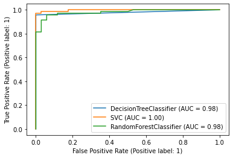

```python
# Plotting the ROC curve for the three tuned models

models = [dt, svc, rf]
ax = plt.gca()
for i in models:
    plot_roc_curve(i, test_features_best, test_class,ax=ax)
```

Highest accuracy score of 97.12%, F1 score of 0.978417 and the roc value of 0.964182 was obtained from the Support vector classifier algorithm after the tuning of hyperparameters.